# AE 23: North Carolina Voting

### Assignments

- [HW 03](https://sta199-fa20-002.netlify.app/hw/hw-03.html) due Nov 8 at 11:59p
- [Stats Exp #2](https://sta199-fa20-002.netlify.app/hw/stat-experience.html) due Nov 8 at 11:59p
  - No lecture Wednesday

### Tea with a TA

Hang out with the TAs from STA 199! This is a casual conversation and a fun opportunity to meet the members of the STA 199 teaching team. The only rule is these can’t turn into office hours!

Tea with a TA counts as a statistics experience.

[**Caroline Levenson**](https://www.linkedin.com/in/carolinelevenson/), **TODAY 1p - 2p**

- [Click here](https://forms.gle/FucAXE6bLeJVyqRY9) to sign up

### Nov 3 is Election Day!

If you’re eligible, VOTE! Find out more information: https://vote.duke.edu/

### Other events

[Electronic Undergraduate Statistics Research Conference (eUSR)](https://www.causeweb.org/usproc/eusrc/2020) Nov 6, 11:30a - 4:40p

- [Click here](https://www.causeweb.org/usproc/eusrc/2020/register) to register

## Exercises

Today’s data set comes from the [US Elections Project]((https://electproject.github.io/Early-Vote-2020G/NC.html). We will focus specifically on early voting data for North Carolina.

The variables are

- `name`: county name
- `regstrd`: number of registered voters
- `voted`: number of individuals who have voted
- `mailed`: number of mail ballots returned
- `rejectd`: number of mail ballots rejected
- `ml_rqst`: number of mail ballots requested

We first read in the file `nc_votes.shp` with the `st_read` function, saving as `nc_votes`.

```r
nc_votes <- st_read("data/nc_votes.shp", quiet = TRUE)
```

### Exercise 1

Carefully examine `nc_votes`. How does it differ from the data frames we have seen before? What type of geometry is associated with each simple feature?

### Exercise 2

Let’s use `nc_votes` to create a map of North Carolina.

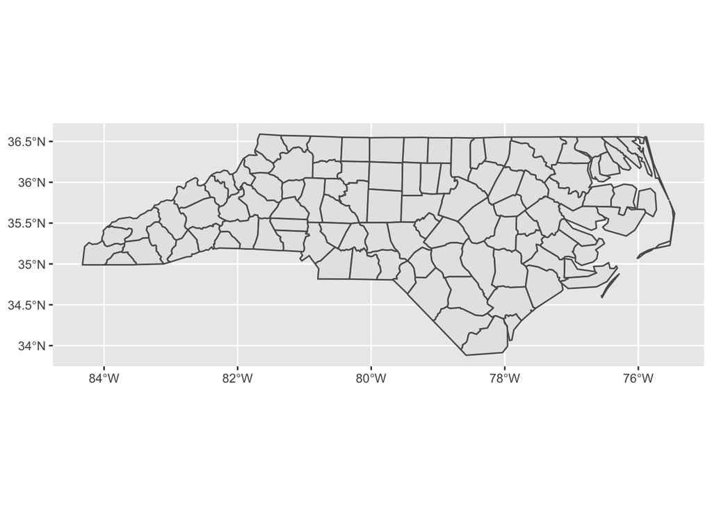

```r
ggplot(nc_votes) +
  geom_sf()
```

Starting with the code above, update the visualization so that the counties have a fill color corresponding to the percentage of mail-in ballots that were requested. Include informative labels, colors and any other aesthetics.

### Exercise 3

4. Create a map of North Carolina where the counties have a fill color corresponding to the percentage of votes that were cast by mail. Include informative labels, colors and any other aesthetics.

### Exercise 4

Create an effective spatial data visualization using these data exploring a topic of your choosing.

Read more about factors to consider when creating election maps: https://www.nytimes.com/interactive/2020/10/30/opinion/election-results-maps.html